# Case Study: Bellabeat

Ahmet Tabakoğlu

2024-02-06

# **How Can a Wellness Technology Company Play It Smart?**

## **Scenario**

[Bellabeat](https://bellabeat.com/) is a high-tech manufacturer of health-focused products for women. Their products include wearable smart jewelry, smart bottles, health tracking apps, and membership programs for personal guidance. The co-founders of the company believe that analyzing smart device fitness data could help unlock new growth opportunities for the company so that they become more successful in the global smart device market.

## **Ask**

#### **Who are the key stakeholders?**

1. Urška Sršen: Bellabeat’s co-founder and Chief Creative Officer
2. Sando Mur: Mathematician and Bellabeat’s co-founder; key member of the Bellabeat executive team
3. Bellabeat marketing analytics team: A team of data analysts responsible for collecting, analyzing, and reporting data that helps guide Bellabeat’s marketing strategy

#### **What are the Bellabeat products?**

1. Bellabeat app: The Bellabeat app provides users with health data related to their activity, sleep, stress, menstrual cycle, and mindfulness habits. This data can help users better understand their current habits and make healthy decisions. The Bellabeat app connects to their line of smart wellness products.
2. Leaf: Bellabeat’s classic wellness tracker can be worn as a bracelet, necklace, or clip. The Leaf tracker connects to the Bellabeat app to track activity, sleep, and stress.
3. Time: This wellness watch combines the timeless look of a classic timepiece with smart technology to track user activity, sleep, and stress. The Time watch connects to the Bellabeat app to provide you with insights into your daily wellness.
4. Spring: This is a water bottle that tracks daily water intake using smart technology to ensure that you are appropriately hydrated throughout the day. The Spring bottle connects to the Bellabeat app to track your hydration levels.
5. Bellabeat membership: Bellabeat also offers a subscription-based membership program for users. Membership gives users 24/7 access to fully personalized guidance on nutrition, activity, sleep, health and beauty, and mindfulness based on their lifestyle and goals.

#### **What is the business task?**

Analyze FitBit smart device data to gain insight into how consumers are using their smart devices.

#### **Key Questions**

1. What are some trends in smart device usage?
2. How could these trends apply to Bellabeat customers?
3. How could these trends help influence Bellabeat marketing strategy?

## **Prepare**

#### **Data Selection**

The following data tables from the FitBit dataset has been selected:

```markdown
dailyActivity_merged.csv
sleepDay_merged.csv
```

Since the daily activity data already includes daily steps, daily calories, and daily intensities, it provides a comprehensive and detailed summary. Additionally, daily sleep data will be used in the analysis in order to find out the relations.

## **Process**

In this phase, we will use R to process the data. After setting up the environment, we will import and clean the data by following some steps.

#### **Loading the Packages and Importing the Data**

First, the necessary packages are installed and loaded.

```r
library(tidyverse)
library(skimr)
library(here)
library(janitor)
library(ggplot2)
library(lubridate)
library(dplyr)
library(scales)
```

Then, the data is imported.

```r
daily_activity <- read.csv("FitBit/dailyActivity_merged.csv")
sleep_day <- read.csv("FitBit/sleepDay_merged.csv")
```

#### **Exploring the Data**

Here, each data frame will be examined in order to find their commonalities and detect their aspects.

```r
head(daily_activity)
```

```
##           Id ActivityDate TotalSteps TotalDistance TrackerDistance
## 1 1503960366    4/12/2016      13162          8.50            8.50
## 2 1503960366    4/13/2016      10735          6.97            6.97
## 3 1503960366    4/14/2016      10460          6.74            6.74
## 4 1503960366    4/15/2016       9762          6.28            6.28
## 5 1503960366    4/16/2016      12669          8.16            8.16
## 6 1503960366    4/17/2016       9705          6.48            6.48
##   LoggedActivitiesDistance VeryActiveDistance ModeratelyActiveDistance
## 1                        0               1.88                     0.55
## 2                        0               1.57                     0.69
## 3                        0               2.44                     0.40
## 4                        0               2.14                     1.26
## 5                        0               2.71                     0.41
## 6                        0               3.19                     0.78
##   LightActiveDistance SedentaryActiveDistance VeryActiveMinutes
## 1                6.06                       0                25
## 2                4.71                       0                21
## 3                3.91                       0                30
## 4                2.83                       0                29
## 5                5.04                       0                36
## 6                2.51                       0                38
##   FairlyActiveMinutes LightlyActiveMinutes SedentaryMinutes Calories
## 1                  13                  328              728     1985
## 2                  19                  217              776     1797
## 3                  11                  181             1218     1776
## 4                  34                  209              726     1745
## 5                  10                  221              773     1863
## 6                  20                  164              539     1728
```

```r
glimpse(daily_activity)
```

```
## Rows: 940
## Columns: 15
## $ Id                       <dbl> 1503960366, 1503960366, 1503960366, 150396036…
## $ ActivityDate             <chr> "4/12/2016", "4/13/2016", "4/14/2016", "4/15/…
## $ TotalSteps               <int> 13162, 10735, 10460, 9762, 12669, 9705, 13019…
## $ TotalDistance            <dbl> 8.50, 6.97, 6.74, 6.28, 8.16, 6.48, 8.59, 9.8…
## $ TrackerDistance          <dbl> 8.50, 6.97, 6.74, 6.28, 8.16, 6.48, 8.59, 9.8…
## $ LoggedActivitiesDistance <dbl> 0, 0, 0, 0, 0, 0, 0, 0, 0, 0, 0, 0, 0, 0, 0, …
## $ VeryActiveDistance       <dbl> 1.88, 1.57, 2.44, 2.14, 2.71, 3.19, 3.25, 3.5…
## $ ModeratelyActiveDistance <dbl> 0.55, 0.69, 0.40, 1.26, 0.41, 0.78, 0.64, 1.3…
## $ LightActiveDistance      <dbl> 6.06, 4.71, 3.91, 2.83, 5.04, 2.51, 4.71, 5.0…
## $ SedentaryActiveDistance  <dbl> 0, 0, 0, 0, 0, 0, 0, 0, 0, 0, 0, 0, 0, 0, 0, …
## $ VeryActiveMinutes        <int> 25, 21, 30, 29, 36, 38, 42, 50, 28, 19, 66, 4…
## $ FairlyActiveMinutes      <int> 13, 19, 11, 34, 10, 20, 16, 31, 12, 8, 27, 21…
## $ LightlyActiveMinutes     <int> 328, 217, 181, 209, 221, 164, 233, 264, 205, …
## $ SedentaryMinutes         <int> 728, 776, 1218, 726, 773, 539, 1149, 775, 818…
## $ Calories                 <int> 1985, 1797, 1776, 1745, 1863, 1728, 1921, 203…
```

```r
n_distinct(daily_activity$Id)
```

```
## [1] 33
```

```r
sum(is.na(daily_activity))
```

```
## [1] 0
```

It can be confirmed that *daily_activity* data frame was loaded correctly. It consists of 15 attributes and 940 observations. There are 33 unique ID’s which means that there are 33 unique participants who contributed to the collection of that data. Finally, there are no NA values in the data.

```r
head(sleep_day)
```

```
##           Id              SleepDay TotalSleepRecords TotalMinutesAsleep
## 1 1503960366 4/12/2016 12:00:00 AM                 1                327
## 2 1503960366 4/13/2016 12:00:00 AM                 2                384
## 3 1503960366 4/15/2016 12:00:00 AM                 1                412
## 4 1503960366 4/16/2016 12:00:00 AM                 2                340
## 5 1503960366 4/17/2016 12:00:00 AM                 1                700
## 6 1503960366 4/19/2016 12:00:00 AM                 1                304
##   TotalTimeInBed
## 1            346
## 2            407
## 3            442
## 4            367
## 5            712
## 6            320
```

```r
glimpse(sleep_day)
```

```
## Rows: 413
## Columns: 5
## $ Id                 <dbl> 1503960366, 1503960366, 1503960366, 1503960366, 150…
## $ SleepDay           <chr> "4/12/2016 12:00:00 AM", "4/13/2016 12:00:00 AM", "…
## $ TotalSleepRecords  <int> 1, 2, 1, 2, 1, 1, 1, 1, 1, 1, 1, 1, 1, 1, 1, 1, 1, …
## $ TotalMinutesAsleep <int> 327, 384, 412, 340, 700, 304, 360, 325, 361, 430, 2…
## $ TotalTimeInBed     <int> 346, 407, 442, 367, 712, 320, 377, 364, 384, 449, 3…
```

```r
n_distinct(sleep_day$Id)
```

```
## [1] 24
```

```r
sum(is.na(sleep_day))
```

```
## [1] 0
```

We can confirm that *sleep_day* data frame was also loaded correctly. It consists of 5 attributes and 413 observations. There are 24 unique ID’s which means that there are 24 unique participants who contributed to the collection of that data. Finally, there are no NA values in the data.

#### **Data Cleaning and Manipulation**

1. As mentioned in the previous step, both data frames do not contain any NA entries. Hence, no operation is needed.
2. Duplicate entries are removed from both data frames.

```r
daily_activity <-daily_activity[!duplicated(daily_activity), ]
glimpse(daily_activity)
```

```
## Rows: 940
## Columns: 15
## $ Id                       <dbl> 1503960366, 1503960366, 1503960366, 150396036…
## $ ActivityDate             <chr> "4/12/2016", "4/13/2016", "4/14/2016", "4/15/…
## $ TotalSteps               <int> 13162, 10735, 10460, 9762, 12669, 9705, 13019…
## $ TotalDistance            <dbl> 8.50, 6.97, 6.74, 6.28, 8.16, 6.48, 8.59, 9.8…
## $ TrackerDistance          <dbl> 8.50, 6.97, 6.74, 6.28, 8.16, 6.48, 8.59, 9.8…
## $ LoggedActivitiesDistance <dbl> 0, 0, 0, 0, 0, 0, 0, 0, 0, 0, 0, 0, 0, 0, 0, …
## $ VeryActiveDistance       <dbl> 1.88, 1.57, 2.44, 2.14, 2.71, 3.19, 3.25, 3.5…
## $ ModeratelyActiveDistance <dbl> 0.55, 0.69, 0.40, 1.26, 0.41, 0.78, 0.64, 1.3…
## $ LightActiveDistance      <dbl> 6.06, 4.71, 3.91, 2.83, 5.04, 2.51, 4.71, 5.0…
## $ SedentaryActiveDistance  <dbl> 0, 0, 0, 0, 0, 0, 0, 0, 0, 0, 0, 0, 0, 0, 0, …
## $ VeryActiveMinutes        <int> 25, 21, 30, 29, 36, 38, 42, 50, 28, 19, 66, 4…
## $ FairlyActiveMinutes      <int> 13, 19, 11, 34, 10, 20, 16, 31, 12, 8, 27, 21…
## $ LightlyActiveMinutes     <int> 328, 217, 181, 209, 221, 164, 233, 264, 205, …
## $ SedentaryMinutes         <int> 728, 776, 1218, 726, 773, 539, 1149, 775, 818…
## $ Calories                 <int> 1985, 1797, 1776, 1745, 1863, 1728, 1921, 203…
```

There is no change in the number of observations, so there are no duplicate entries in the *daily_activity* data frame.

```r
sleep_day <-sleep_day[!duplicated(sleep_day), ]
glimpse(sleep_day)
```

```
## Rows: 410
## Columns: 5
## $ Id                 <dbl> 1503960366, 1503960366, 1503960366, 1503960366, 150…
## $ SleepDay           <chr> "4/12/2016 12:00:00 AM", "4/13/2016 12:00:00 AM", "…
## $ TotalSleepRecords  <int> 1, 2, 1, 2, 1, 1, 1, 1, 1, 1, 1, 1, 1, 1, 1, 1, 1, …
## $ TotalMinutesAsleep <int> 327, 384, 412, 340, 700, 304, 360, 325, 361, 430, 2…
## $ TotalTimeInBed     <int> 346, 407, 442, 367, 712, 320, 377, 364, 384, 449, 3…
```

The number of observations decreased by 3, so there were 3 duplicate entries in the *sleep_day* data frame and we eliminated them.

3. The format of the “Id” columns are converted to character data type for both data frames as the entries will not be used for any numerical operation.
4. The format of the “ActivityDate” column for the *daily_activity* data frame and the “SleepDay” column for the *sleep_day* data frame are converted to date data type. Then, the columns are renamed as “Date” in order to make them common attributes for two data frames.

```r
daily_activity <- daily_activity %>%
  mutate(Id = as.character(Id)) %>%
  mutate(ActivityDate = as.Date(ActivityDate, "%m/%d/%y")) %>%
  rename("Date" = "ActivityDate")

sleep_day <- sleep_day %>%
  mutate(Id = as.character(Id)) %>%
  mutate(SleepDay = as.Date(SleepDay, "%m/%d/%y")) %>%
  rename("Date" = "SleepDay")
```

#### **Merging the Data Frames**

In this step, *daily_activity* and *sleep_day* data frames will be merged to become ready for the analysis phase.

```r
merged_data <- daily_activity %>%
  left_join(sleep_day, by = c("Id", "Date"))
```

A “day_of_week” column will also be added to the merged data frame in order to analyze the data based on weekdays.

```r
merged_data <- merged_data %>%
  mutate(day_of_week = weekdays(Date))
```

## **Analyze**

### **Summary Statistics and Findings**

```r
merged_data %>%
  select(TotalSteps, TotalDistance, VeryActiveMinutes, FairlyActiveMinutes, LightlyActiveMinutes, SedentaryMinutes, Calories, TotalMinutesAsleep, TotalTimeInBed) %>%
  summary()
```

```
##    TotalSteps    TotalDistance    VeryActiveMinutes FairlyActiveMinutes
##  Min.   :    0   Min.   : 0.000   Min.   :  0.00    Min.   :  0.00
##  1st Qu.: 3790   1st Qu.: 2.620   1st Qu.:  0.00    1st Qu.:  0.00
##  Median : 7406   Median : 5.245   Median :  4.00    Median :  6.00
##  Mean   : 7638   Mean   : 5.490   Mean   : 21.16    Mean   : 13.56
##  3rd Qu.:10727   3rd Qu.: 7.713   3rd Qu.: 32.00    3rd Qu.: 19.00
##  Max.   :36019   Max.   :28.030   Max.   :210.00    Max.   :143.00
##
##  LightlyActiveMinutes SedentaryMinutes    Calories    TotalMinutesAsleep
##  Min.   :  0.0        Min.   :   0.0   Min.   :   0   Min.   : 58.0
##  1st Qu.:127.0        1st Qu.: 729.8   1st Qu.:1828   1st Qu.:361.0
##  Median :199.0        Median :1057.5   Median :2134   Median :432.5
##  Mean   :192.8        Mean   : 991.2   Mean   :2304   Mean   :419.2
##  3rd Qu.:264.0        3rd Qu.:1229.5   3rd Qu.:2793   3rd Qu.:490.0
##  Max.   :518.0        Max.   :1440.0   Max.   :4900   Max.   :796.0
##                                                       NA's   :530
##  TotalTimeInBed
##  Min.   : 61.0
##  1st Qu.:403.8
##  Median :463.0
##  Mean   :458.5
##  3rd Qu.:526.0
##  Max.   :961.0
##  NA's   :530
```

According to the summary statistics, an average user;

1. Takes 7638 steps and travels 5.49 km per day.
2. Burns 2304 calories and sleeps 419.2 minutes while spending her time in bed for 458.5 minutes per day.
3. Spends most of her time sedentary.

### **Daily Analysis**

```r
daily_statistics <- merged_data %>%
  group_by(day_of_week)  %>%
  summarise(TotalMinsAsleep = mean(TotalMinutesAsleep, na.rm = TRUE),
            TotalMinsInBed = mean(TotalTimeInBed, na.rm = TRUE),
            CaloriesBurnt = mean(Calories, na.rm = TRUE),
            TotalStepsTaken = mean(TotalSteps, na.rm = TRUE),
            TotalDistanceTraveled = mean(TotalDistance, na.rm = TRUE),
            TotalVeryActiveMins = mean(VeryActiveMinutes, na.rm = TRUE),
            TotalFairlyActiveMins = mean(FairlyActiveMinutes, na.rm = TRUE),
            TotalLightlyActiveMins = mean(LightlyActiveMinutes, na.rm = TRUE),
            TotalSedentaryMins = mean(SedentaryMinutes, na.rm = TRUE), .groups = 'drop')
daily_statistics <- daily_statistics %>%
  arrange(ordered(day_of_week, levels=c("Monday", "Tuesday", "Wednesday",
                              "Thursday", "Friday", "Saturday", "Sunday"))) %>%
  mutate(TimeSpentAwake = TotalMinsInBed - TotalMinsAsleep)
daily_statistics
```

```
## # A tibble: 7 × 11
##   day_of_week TotalMinsAsleep TotalMinsInBed CaloriesBurnt TotalStepsTaken
##   <chr>                 <dbl>          <dbl>         <dbl>           <dbl>
## 1 Monday                 435.           470.         2303.           7559.
## 2 Tuesday                401.           435.         2200.           7406.
## 3 Wednesday              405.           445.         2332.           7448.
## 4 Thursday               419.           460.         2355.           8153.
## 5 Friday                 453.           504.         2263            6933.
## 6 Saturday               420.           457.         2324.           7781.
## 7 Sunday                 405.           443.         2356.           8125.
## # ℹ 6 more variables: TotalDistanceTraveled <dbl>, TotalVeryActiveMins <dbl>,
## #   TotalFairlyActiveMins <dbl>, TotalLightlyActiveMins <dbl>,
## #   TotalSedentaryMins <dbl>, TimeSpentAwake <dbl>
```

#### Daily Sleep Statistics

```r
daily_sleep <- daily_statistics %>%
  select(day_of_week, TotalMinsAsleep, TotalMinsInBed, TimeSpentAwake)
daily_sleep
```

```
## # A tibble: 7 × 4
##   day_of_week TotalMinsAsleep TotalMinsInBed TimeSpentAwake
##   <chr>                 <dbl>          <dbl>          <dbl>
## 1 Monday                 435.           470.           35.3
## 2 Tuesday                401.           435.           33.6
## 3 Wednesday              405.           445.           39.6
## 4 Thursday               419.           460.           40.8
## 5 Friday                 453.           504.           50.8
## 6 Saturday               420.           457.           37.8
## 7 Sunday                 405.           443.           38.8
```

According to the daily sleep data, people tend to sleep more on Fridays, with an approximate 7.5 hours of sleep time. They also spend more time in total and stay awake longer in bed on Fridays. When weekdays and weekends are compared, people sleep more on weekdays than on weekends on average.

#### Daily Statistics of Calories Burnt

```r
daily_calories <- daily_statistics %>%
  select(day_of_week, CaloriesBurnt)
daily_calories
```

```
## # A tibble: 7 × 2
##   day_of_week CaloriesBurnt
##   <chr>               <dbl>
## 1 Monday              2303.
## 2 Tuesday             2200.
## 3 Wednesday           2332.
## 4 Thursday            2355.
## 5 Friday              2263
## 6 Saturday            2324.
## 7 Sunday              2356.
```

According to the daily calories data, people tend to burn less calories on Tuesdays with approximately 2200 calories. When weekdays and weekends are compared, people burn more calories on weekends than on weekdays on average.

#### Daily Steps and Distances

```r
daily_steps <- daily_statistics %>%
  select(day_of_week, TotalStepsTaken, TotalDistanceTraveled)
daily_steps
```

```
## # A tibble: 7 × 3
##   day_of_week TotalStepsTaken TotalDistanceTraveled
##   <chr>                 <dbl>                 <dbl>
## 1 Monday                7559.                  5.49
## 2 Tuesday               7406.                  5.31
## 3 Wednesday             7448.                  5.31
## 4 Thursday              8153.                  5.85
## 5 Friday                6933.                  5.03
## 6 Saturday              7781.                  5.55
## 7 Sunday                8125.                  5.83
```

According to the daily steps and distances data, people tend to walk more on Thursdays and Sundays with more than 8100 steps and 5.8 km distance. When weekdays and weekends are compared, people walk more on weekends than on weekdays on average.

#### Daily Active Minutes

```r
daily_active_mins <- daily_statistics %>%
  select(day_of_week, TotalVeryActiveMins, TotalFairlyActiveMins,
         TotalLightlyActiveMins, TotalSedentaryMins)
daily_active_mins
```

```
## # A tibble: 7 × 5
##   day_of_week TotalVeryActiveMins TotalFairlyActiveMins TotalLightlyActiveMins
##   <chr>                     <dbl>                 <dbl>                  <dbl>
## 1 Monday                     20.8                  13.1                   190.
## 2 Tuesday                    19.4                  12.0                   185.
## 3 Wednesday                  20.1                  12.1                   204.
## 4 Thursday                   21.9                  15.2                   207.
## 5 Friday                     20.0                  14.5                   174.
## 6 Saturday                   23.1                  14                     192.
## 7 Sunday                     23.0                  14.3                   197.
## # ℹ 1 more variable: TotalSedentaryMins <dbl>
```

According to the daily active minutes data, it can be fair to comment that people tend to rest more and spend more very active minutes by exercising on weekends. It can be said that people have less opportunity to rest and spend active minutes on weekdays due to work or school, and they spend most of their active time lightly active.

## **Share**

In this phase, the findings in the analysis phase will be explained using visualizations.

### **Correlations**

First, the relationships between variables will be detected and explained.

#### Relationship Between Total Steps Taken and Calories Burnt

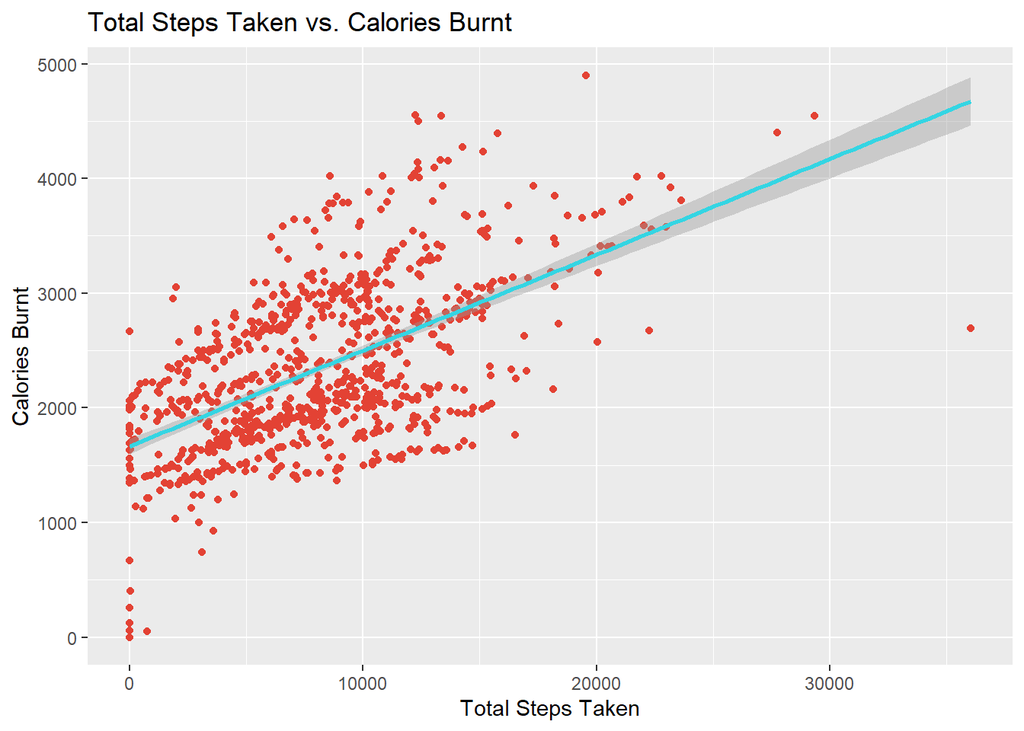

```r
ggplot(data = merged_data, mapping = aes(x=TotalSteps, y=Calories)) +
  geom_point(color = "#e34234") +
  stat_smooth(method = "lm", color = "#34d5e3") +
  labs(x = "Total Steps Taken", y = "Calories Burnt", title = "Total Steps Taken vs. Calories Burnt")
```

According to the scatter plot above, we can say that calories burnt are positively correlated with the steps taken.

#### Relationship Between Very Active Minutes Spent and Calories Burnt

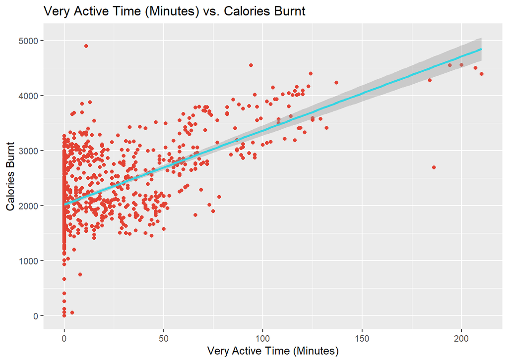

```r
ggplot(data = merged_data, mapping = aes(x=VeryActiveMinutes, y=Calories)) +
  geom_point(color = "#e34234") +
  stat_smooth(method = "lm", color = "#34d5e3") +
  labs(x = "Very Active Time (Minutes)", y = "Calories Burnt", title = "Very Active Time (Minutes) vs. Calories Burnt")
```

According to the scatter plot above, we can say that calories burnt are positively correlated with the very active minutes spent.

### **Daily Statistics**

Now, the daily statistics interpreted in the analyze phase will be visualized.

#### Average Sleep Time per Day

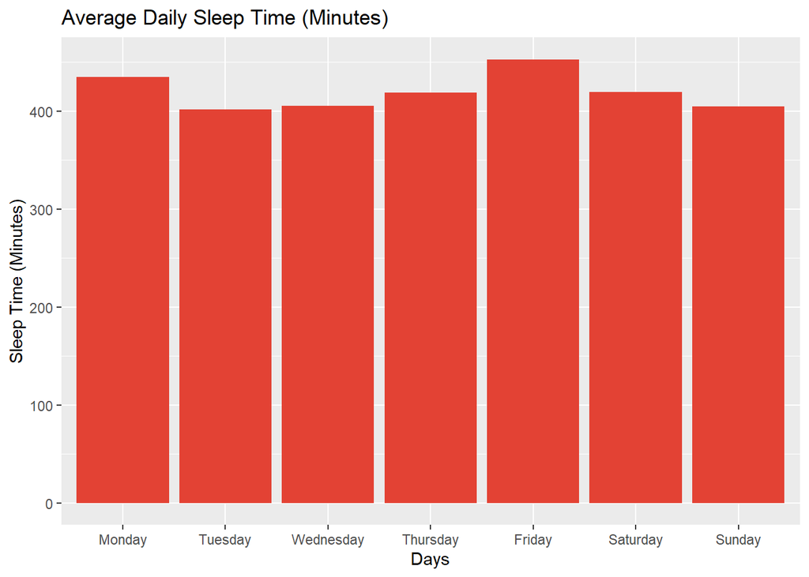

```r
ggplot(data = daily_sleep, aes(x= factor(day_of_week, levels = c("Monday", "Tuesday", "Wednesday", "Thursday", "Friday", "Saturday", "Sunday")), y= TotalMinsAsleep)) +
  geom_bar(stat='identity', fill = "#e34234") +
  labs(x = "Days", y = "Sleep Time (Minutes)", title = "Average Daily Sleep Time (Minutes)")
```

#### Average Calories Burnt per Day

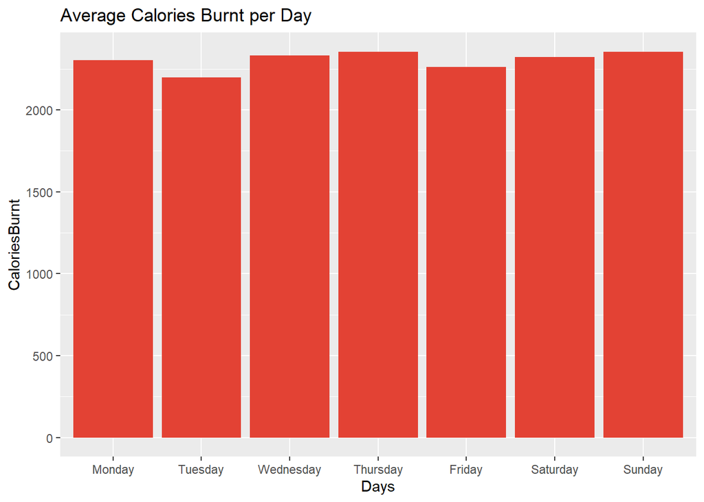

```r
ggplot(data = daily_calories, aes(x= factor(day_of_week, levels = c("Monday", "Tuesday", "Wednesday", "Thursday", "Friday", "Saturday", "Sunday")), y= CaloriesBurnt)) +
  geom_bar(stat='identity', fill = "#e34234") +
  labs(x = "Days", y = "CaloriesBurnt", title = "Average Calories Burnt per Day")
```

#### Average Steps Taken per Day

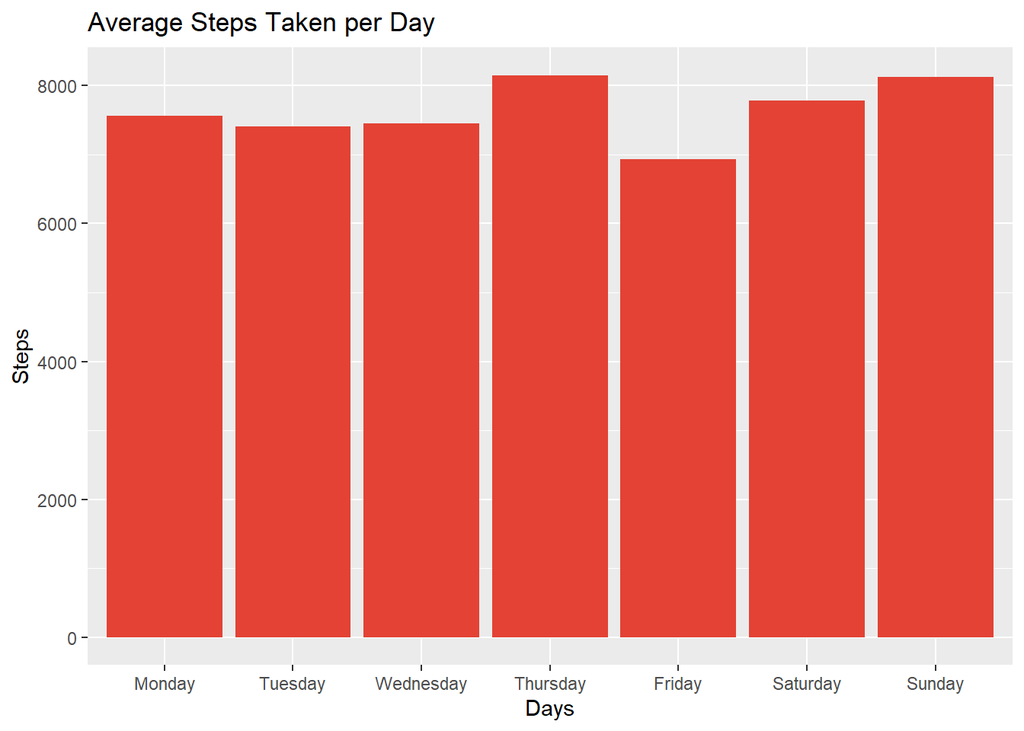

```r
ggplot(data = daily_steps, aes(x= factor(day_of_week, levels = c("Monday", "Tuesday", "Wednesday", "Thursday", "Friday", "Saturday", "Sunday")), y= TotalStepsTaken)) +
  geom_bar(stat='identity', fill = "#e34234") +
  labs(x = "Days", y = "Steps", title = "Average Steps Taken per Day")
```

#### Distribution of Active and Sedentary Minutes

```r
very_active_mins <- sum(merged_data$VeryActiveMinutes)
fairly_active_mins <- sum(merged_data$FairlyActiveMinutes)
lightly_active_mins <- sum(merged_data$LightlyActiveMinutes)
sedentary_mins <- sum(merged_data$SedentaryMinutes)
total_mins <- very_active_mins + fairly_active_mins + lightly_active_mins + sedentary_mins

dist_active_mins <- data.frame(
  Activity_Level = c("Very Active", "Fairly Active", "Lightly Active", "Sedentary"),
  Mins = c(very_active_mins, fairly_active_mins, lightly_active_mins, sedentary_mins)
)

dist_active_mins$Activity_Level_and_Percentages <- paste0(dist_active_mins$Activity_Level,' [',100*round(dist_active_mins$Mins/total_mins,4),'%',']')
```

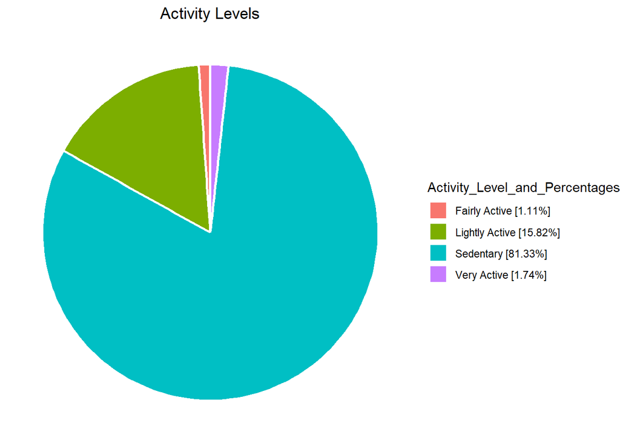

```r
ggplot(dist_active_mins, aes(x="", y=Mins, fill=Activity_Level_and_Percentages)) +
  geom_bar(stat="identity", width=1, linewidth=1, color="white") +
  coord_polar("y", start=0) +
  theme_void()+
  labs(title = "Activity Levels")+
  theme(plot.title = element_text(hjust = 0.5))
```

## **Act**

In the last phase, we will clarify the trends in smart device usage based on the data we analyzed, and make recommendations so that we can turn our insights into actions.

#### **Recommendations**

1. A summary of total steps taken per day can be shared with the users weekly. They can set their own goals on how many steps they want to take per day, and get an encouraging notification if they fail. There can also be a streak tracker for how many consecutive days the user achieves the daily goal to keep the user motivated.
2. It should be encouraged that users spend more very active time even if it is short, rather than long but lightly active or sedentary time. The live data can be shared with the users so that they can set their goals on how much very active time they want to spend.
3. Users should be notified after a certain time of inactivity in order to shorten their sedentary time.
4. Professionals recommend adults get 7-9 hours of sleep a day. Users should be warned on days when they sleep less or more than this range and the importance of sleep for health should be emphasized. A streak tracker for consecutive days with appropriate amount of sleep can be used in order to motivate the users.
5. All these suggestions can be integrated into a membership plan and presented to users, enabling the company to create an additional source of income. By offering a free trial period, users can become more familiar with the features. In this way, we can reach more users, collect more data, and improve the features for our own users by analyzing our own data.